# 로지스틱 회귀 (Logistic Regression) 실습 - 위스콘신 유방암 데이터 예측

## 실습 목적

- 종양의 크기, 모양 등 다양한 속성값을 기반으로 악성 종양인지 양성 종양인지를 분류함.
- 스케일링 해보기 실습

## 실습 순서 이해

다음 순서로 실습을 해 본다.

- (1) 라이브러리/모듈 import
- (2) 위스콘신 유방암 데이터 세트 호출 (load_breast_cancer())
- (3) 데이터를 학습데이터와 테스트 데이터로 분리
- (4) 로지스틱 회귀분석 실시

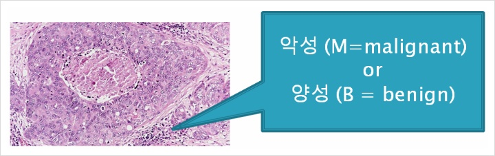

악성(malignant) - 암o (1) 양성(benign) - 암x (0)

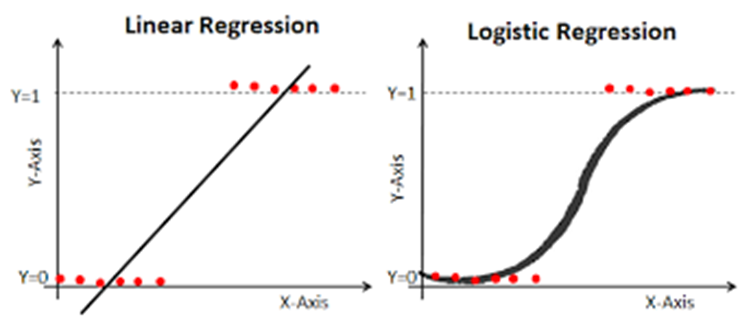

# 1 데이터 불러오기

## (1) 라이브러리/모듈 import

```python
import pandas as pd
import matplotlib.pyplot as plt
import warnings
warnings.filterwarnings('ignore')
```

- 로지스틱 회귀분석과 train_test_split 호출

```python
from sklearn.linear_model import LogisticRegression
```

```python
from sklearn.model_selection import train_test_split
```

- 사이킷런 데이터세트 load_breat_cancer 및 정확도 확인을 위해 accuracy_score 호출

```python
from sklearn.datasets import load_breast_cancer
```

```python
from sklearn.metrics import accuracy_score
```

## (2) 데이터셋 로드

sklearn 의 datasets는 sklearn.utils.Bunch라는 key-value 형식으로 구성되는 딕셔너리 형 타입과 유사한 구조를 가지고 있습니다.

```python
dataset = load_breast_cancer()
```

```python
type(dataset)
```

[output not shown]

```python
print(dataset)
```

[output not shown]

```python
# key만 뽑아서 보자.
dataset.keys()
```

[output not shown]

```python
#피쳐 이름을 보자.
print(dataset.feature_names)
```

[output not shown]

**보기 쉽게 dataframe으로 만들어보자.**

- feature값(data)과 feature_names만으로 dataframe 생성

```python
cancer_df = pd.DataFrame( data= dataset.data, columns=dataset.feature_names)
```

```python
cancer_df.head()
```

[output not shown]

- target 열 추가하기

```python
cancer_df['target'] = dataset.target
```

```python
cancer_df.head(3)
```

[output not shown]

```python
#targer의 데이터 크기를 살펴보자.
print(cancer_df['target'].value_counts())
```

[output not shown]

# 2. LogisticRegression 로 예측해 보기.

- 피쳐들만 X_feature, 타깃(목표변수)를 y_label
- axis = 1 : 열방향,(즉, 열전체)

```python
X_features = cancer_df.drop('target', axis=1)
y_label = cancer_df['target']
```

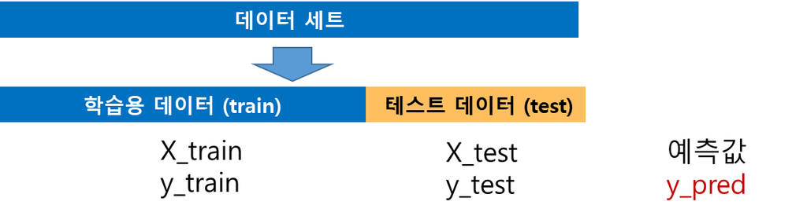

```python
#학습과 테스트 데이터로 구분 7:3
X_train , X_test, y_train , y_test = train_test_split(X_features, y_label, test_size=0.3, random_state=0)
```

- 인수: x값들, y값들, test_size(테스트데이터 크기), random_state(무작위 추출할 때 매번 변하지 않게 하기 위해 설정)

```python
#로지스틱회귀분석하기
#Logistic Regression _ classification 약자로 lr_clf라 쓰자.

lr_clf = LogisticRegression()
```

```python
#훈련하기
lr_clf.fit(X_train, y_train)
```

```python
#예측하기
y_pred = lr_clf.predict(X_test)
```

```python
#예측력 보기
print('accuracy: {:0.3f}'.format(accuracy_score(y_test, y_pred)))
```

[output not shown]